# TP 4 : ANOVA - Exercice 1

Tracy ANDRE

May 3rd, 2023

# Exercice 1 : ANOVA à un facteur

#### QUESTION 1 : IMPORTATION DES DONNEES

NB : Y en fonction de X

*Objectif de l’exercice : savoir si les caractéristiques nutritionnelles sont liées au type de viande utilisée.*

*Différence entre ANOVA et summary : Anova = test par facteur et summary test sur les paramètres*

#### **Q1 - Importation des données**

```r
setwd("C:/Users/andre/OneDrive/Documents/S6/Stats/TP4 - ANOVA/TP4_Donnees")
hotdog <- read.table("hotdogs.txt", header=T)
attach(hotdog)
head(hotdog)
```

|  | Type | Calories | Sodium |
| --- | --- | --- | --- |
| 1 | 1 | 186 | 495 |
| 2 | 1 | 181 | 477 |
| 3 | 1 | 176 | 425 |
| 4 | 1 | 149 | 322 |
| 5 | 1 | 184 | 482 |
| 6 | 1 | 190 | 587 |

```r
summary(hotdog)
```

```
      Type          Calories         Sodium
 Min.   :1.000   Min.   : 70.0   Min.   :144.0
 1st Qu.:1.000   1st Qu.:131.5   1st Qu.:365.0
 Median :2.000   Median :144.0   Median :405.0
 Mean   :1.982   Mean   :144.1   Mean   :424.6
 3rd Qu.:3.000   3rd Qu.:172.5   3rd Qu.:501.0
 Max.   :4.000   Max.   :195.0   Max.   :645.0
```

```r
table(hotdog$Type)
```

```
 1  2  3  4
20 17 17  1
```

```r
hotdog = hotdog[-which(hotdog$Type==4),]
hotdog
```

|  | Type | Calories | Sodium |
| --- | --- | --- | --- |
| 1 | 1 | 186 | 495 |
| 2 | 1 | 181 | 477 |
| 3 | 1 | 176 | 425 |
| 4 | 1 | 149 | 322 |
| 5 | 1 | 184 | 482 |
| 6 | 1 | 190 | 587 |
| 7 | 1 | 158 | 370 |
| 8 | 1 | 139 | 322 |
| 9 | 1 | 175 | 479 |
| 10 | 1 | 148 | 375 |

[output cut: 44 more lines]

La cmd précédente permet d’enlever le Type n°4 car nous n’avons qu’une valeur pour ce type, ce qui n’est pas vrmt rpztatif.

```r
hotdog$Type=as.factor(hotdog$Type)
hotdog
```

|  | Type | Calories | Sodium |
| --- | --- | --- | --- |
| 1 | 1 | 186 | 495 |
| 2 | 1 | 181 | 477 |
| 3 | 1 | 176 | 425 |
| 4 | 1 | 149 | 322 |
| 5 | 1 | 184 | 482 |
| 6 | 1 | 190 | 587 |
| 7 | 1 | 158 | 370 |
| 8 | 1 | 139 | 322 |
| 9 | 1 | 175 | 479 |
| 10 | 1 | 148 | 375 |

[output cut: 44 more lines]

Cette cmd permet de convertir le Type (qui est un int) en factor Les facteurs sont utilisées pour rpz des variables qualitatives tq le sexe, la couleur ou le type de traitement d’une expérience. Les facteurs sont stockées sous forme d’entiers où chaque entier rpz une valeur unique de la variable catégorique.

Utile pour effectuer des analyses statistiques tq modèle linéaire ou ANOVA => car nécéssite des variables catégoriques en tant que facteurs

Utilse aussi pour la visualisation de données en utilisant des graphiques

#### **Q2 - STATS DESCRIPTIVES**

*(a)*

*(b)*

**Pour les calories :**

```r
cal <- by(hotdog$Calories, hotdog$Type, summary)
cal
```

```
hotdog$Type: 1
   Min. 1st Qu.  Median    Mean 3rd Qu.    Max.
  111.0   140.5   152.5   156.8   177.2   190.0
------------------------------------------------------------------------
hotdog$Type: 2
   Min. 1st Qu.  Median    Mean 3rd Qu.    Max.
  107.0   139.0   153.0   158.7   179.0   195.0
------------------------------------------------------------------------
hotdog$Type: 3
   Min. 1st Qu.  Median    Mean 3rd Qu.    Max.
   86.0   102.0   113.0   118.8   142.0   152.0
```

**Pour le sodium :**

```r
sod <- by(hotdog$Sodium, hotdog$Type, summary)
sod
```

```
hotdog$Type: 1
   Min. 1st Qu.  Median    Mean 3rd Qu.    Max.
  253.0   321.2   380.5   401.1   477.5   645.0
------------------------------------------------------------------------
hotdog$Type: 2
   Min. 1st Qu.  Median    Mean 3rd Qu.    Max.
  144.0   386.0   405.0   418.5   496.0   545.0
------------------------------------------------------------------------
hotdog$Type: 3
   Min. 1st Qu.  Median    Mean 3rd Qu.    Max.
    357     383     430     459     528     588
```

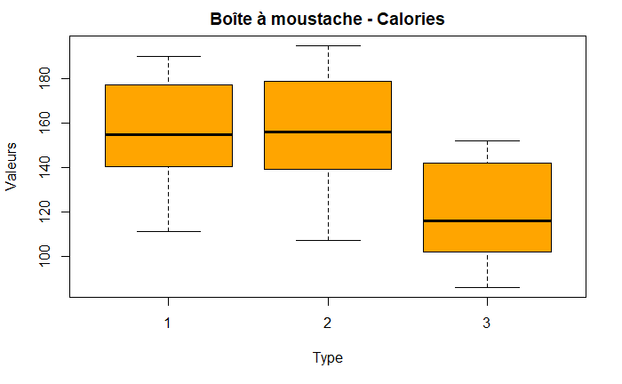

```r
boxplot(cal, main = "Boîte à moustache - Calories", ylab = "Valeurs", xlab= "Type", col="orange")
```

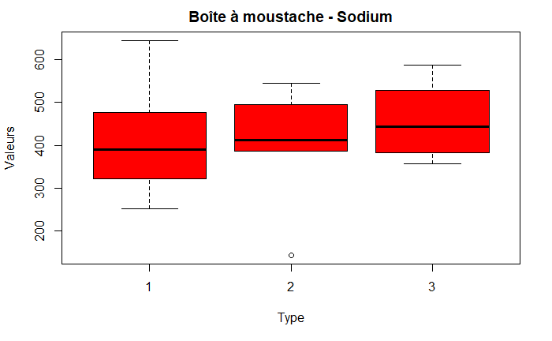

```r
boxplot(sod, main = "Boîte à moustache - Sodium", ylab = "Valeurs", xlab= "Type", col="red")
```

*(c)*

Interprétation d’un boxplot :

- la boite : rpz 50% des données (2ème et 3ème quartile) => la ligne à l’intérieur rpz la ligne médiane
- les moustaches : les valeurs à l’extérieur de la moustache sont extrêmes
  - la symétrie de la boîte à moustache peut indiquer une distribution symétrique
  - si les moustaches sont inégales : indique que la distribution a une variation non uniforme
  - si les moustaches sont rapprochées, les valeurs sont concentrées dans la boite, faible variation
- si on compare plusieurs boxplot :
  - si les médianes sont similaires ou se chevauchent : peut indiquer une similarité dans la distribution
  - si les médiances sont différentes et les boites ne se chevauchent pas => différence significative entre les distributions

Par rapport à notre étude, on peut voir que les 3 boxplots du sodium on à peu près la même médiane. Bien que le type 1 semble avoir une variance plus importante, il semblerait que les 3 Types ont une distribution vis-à-vis du sodium identique. *On ne voit pas de différence significative en terme de sel dans la viande* Quant au calorie, les Types 1 et 2 ont une médiane au même niveau et une variance similaire, ce qui indique donc que ces deux Types on une distribution calorique identique. Ce n’est pas le cas du type 3, qui n’a pas du tout la même valeur de médiane *=> le type 3 de viande semble être nettement moins calorique que le deux autres.*

*NB : quartile : 25%*

**Conclusion : il serait plus intéréssant d’étudier le nombre de calories puisqu’il semble avoir une différence significative entre les Types.**

#### **Q3 - ETUDES DU NOMBRE DE CALORIES**

*(a) Modèle associé à l’expérience*

$$Y_{i,j} = \mu + \alpha_i + \epsilon_i \quad \forall i = 1,2,3 \quad \forall j=1,...,n_i$$

où :

- Yij rpz le nb de calories par hotdog pour le i-ème type de viande de la j-ème marque
- mu est la moye,,e globale des nb de calories par hotdog pour toutes les marques et tous les types de viandes
- alphai est l’effet fixe du i-ème type de viande $
- et l’erreur aléatoire associée à la j-ème obs du i-ème type de viande, **idd et gaussien**

*NB : ici les j vont de 1 à $n_i$ car le modèle n’est pas équilibré*

L’hypothèse nulle pour ce modèle est que les moyennes des nb de calories pour les différents type de viandes sont égales ie :

$$H_0 = \mu_1 = \mu_2 = \mu_3$$

```r
model_calories <- lm(Calories~Type, data=hotdog)
```

Ceci spécifie que Calories est la variable à expliquer et Type est le facteur qui va expliquer la variance.

*(b)*

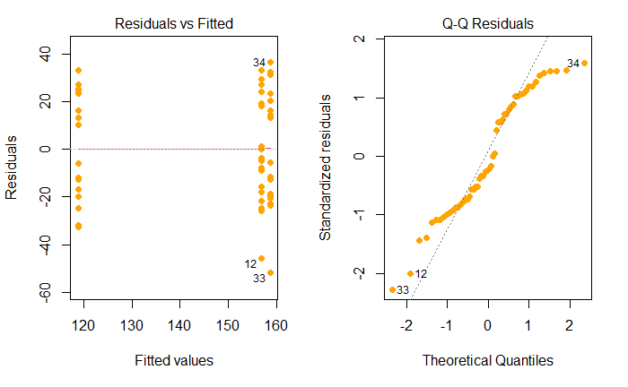

```r
par(mfrow=c(1,2))
plot(model_calories, pch=19, col="orange", which = c(1,2))
par(mfrow=c(1,1))
```

- Graphique de dispersion des résidus :
  - la variance semble constante => homosédasticité vérifiée
  - dispersion aléatoire => pas vérfiée du tout => normal à cause des 3 différents types distincts
- QQ Plot : ce graphe sert à savoir si les résidus suivent une loi normale
  - les pts ne sont pas vrmt alignés sur la droite => donc les résidus ne suivent pas une loi normale

Les hypothèses ne sont pas vérifiées.

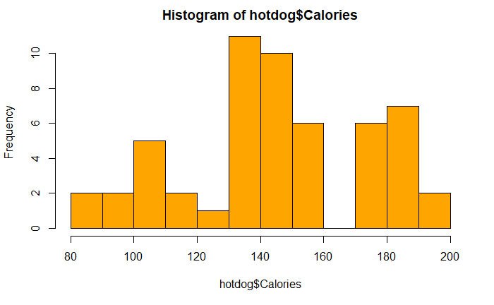

```r
hist(hotdog$Calories, nclass = 10, col="orange")
```

```r
anova(model_calories)
```

```
Analysis of Variance Table

Response: Calories
          Df Sum Sq Mean Sq F value    Pr(>F)
Type       2  17692  8846.1  16.074 3.862e-06 ***
Residuals 51  28067   550.3
---
Signif. codes:  0 ‘***’ 0.001 ‘**’ 0.01 ‘*’ 0.05 ‘.’ 0.1 ‘ ’ 1
```

On peut voir donc que l’hypothèse nulle est très peu probable car la p-value est quasiment nulle. De même que la valeur de F est grande ce qui indique que la variance entre les groupe est grande par rapport à la variance intra-groupe => indique églt qu’il existe une différence significative entre les groupes.

*cf p31 Cours ANOVA* * Df : degree of freedom (dl) * Sum Sq : Somme des carrés (SSM et SSR) * Mean Sq : moyenne des carrés (CMM = SSM/dl-1 et CMR=SSR/dl-1) * Statistique F : F0 = CMM/CMR * p-value

Avec $ H_0 = {_1=_2=_3=0}$

*(d)*

```r
summary(model_calories)
```

```
Call:
lm(formula = Calories ~ Type, data = hotdog)

Residuals:
    Min      1Q  Median      3Q     Max
-51.706 -18.492  -5.278  22.500  36.294

Coefficients:
            Estimate Std. Error t value Pr(>|t|)
(Intercept)  156.850      5.246  29.901  < 2e-16 ***
Type2          1.856      7.739   0.240    0.811
Type3        -38.085      7.739  -4.921 9.39e-06 ***
---
Signif. codes:  0 ‘***’ 0.001 ‘**’ 0.01 ‘*’ 0.05 ‘.’ 0.1 ‘ ’ 1

Residual standard error: 23.46 on 51 degrees of freedom
Multiple R-squared:  0.3866,    Adjusted R-squared:  0.3626
F-statistic: 16.07 on 2 and 51 DF,  p-value: 3.862e-06
```

*Tests sur le modèle des effets (cf p49)*

Contrainte choisie dans ce modèle : $\hat{\alpha_1}$ = 0

Contrainte natuelle :
$$\sum{\alpha_i} = 0$$
en R : rajouter dans le model *contrast = list(Type=“contr.sum”)*

Coefficient de détermination : R² = 0.3626 **correction** *: R²0.38 => on prend la valeur ajustée juste pour les régression multiple* Cela signifie que le modèle explique à 36% la variabilité des données ie la variation des calories en fonction du type. Le reste de la variation est donc attribuable à d’autres facteurs non présents dans cette étude. Le R² n’est pas très grand, cela signifie qu’on peut difficilement dire que le type de viande explique les calories des hotdog

L’écart-type : 23.46

La dernière ligne fournie par la cmd renvoie le résultat du test de Fisher. Ce test permet de déterminer s’il existe une relation significative entre la variable indépendante et les variables dépendantes.

*NB : même teste que dans l’ANOVA (cf plus haut)*

*(e)*

```r
library(emmeans)
emmeans(model_calories, pairwise~Type, adjust="bonferroni")
```

```
$emmeans
 Type emmean   SE df lower.CL upper.CL
 1       157 5.25 51      146      167
 2       159 5.69 51      147      170
 3       119 5.69 51      107      130

Confidence level used: 0.95

$contrasts
 contrast      estimate   SE df t.ratio p.value
 Type1 - Type2    -1.86 7.74 51  -0.240  1.0000
 Type1 - Type3    38.09 7.74 51   4.921  <.0001
 Type2 - Type3    39.94 8.05 51   4.964  <.0001

P value adjustment: bonferroni method for 3 tests
```

Cette cmd calcule les moyennes estimées pour chaque facteur Type ajustement de Bonferroni pour corriger le niveau de significativité, afin de maintenir un taux d’erreur de type I global de 5% *notation : pairwise~Type pour comparer les type deux à deux*

contrast => test si Type1 et Type2 ont les mêmes moyennes

le type 3 est le moins caloriques (119) Il est significativement moins calorique que les deux autres car les p value ajusté est quasi nulle (dans le tableau constraste).

En comparant Type1 - Type2, on retrouve bien le résultat qu’on a trouvé précédemment : avec des moyennes quasi identiques